# Assignment_Pandas_Seaborn2

### **Question 4 - For how many passengers do we have age information (including estimated age)? For how many is the age information missing? What is the age distribution for passengers whose age information is available?**

```python
#Write Your Code here
#For how many passengers do we have age information (including estimated age)?
df
```

|  | survived | pclass | sex | age | sibsp | parch | fare | embarked | class | who | adult_male | deck | embark_town | alive | alone |
| --- | --- | --- | --- | --- | --- | --- | --- | --- | --- | --- | --- | --- | --- | --- | --- |
| 0 | 0 | 3 | male | 22.0 | 1 | 0 | 7.2500 | S | Third | man | True | NaN | Southampton | no | False |
| 1 | 1 | 1 | female | 38.0 | 1 | 0 | 71.2833 | C | First | woman | False | C | Cherbourg | yes | False |
| 2 | 1 | 3 | female | 26.0 | 0 | 0 | 7.9250 | S | Third | woman | False | NaN | Southampton | yes | True |
| 3 | 1 | 1 | female | 35.0 | 1 | 0 | 53.1000 | S | First | woman | False | C | Southampton | yes | False |
| 4 | 0 | 3 | male | 35.0 | 0 | 0 | 8.0500 | S | Third | man | True | NaN | Southampton | no | True |
| ... | ... | ... | ... | ... | ... | ... | ... | ... | ... | ... | ... | ... | ... | ... | ... |
| 886 | 0 | 2 | male | 27.0 | 0 | 0 | 13.0000 | S | Second | man | True | NaN | Southampton | no | True |
| 887 | 1 | 1 | female | 19.0 | 0 | 0 | 30.0000 | S | First | woman | False | B | Southampton | yes | True |
| 888 | 0 | 3 | female | NaN | 1 | 2 | 23.4500 | S | Third | woman | False | NaN | Southampton | no | False |
| 889 | 1 | 1 | male | 26.0 | 0 | 0 | 30.0000 | C | First | man | True | C | Cherbourg | yes | True |
| 890 | 0 | 3 | male | 32.0 | 0 | 0 | 7.7500 | Q | Third | man | True | NaN | Queenstown | no | True |

891 rows × 15 columns

```python
age_count = df['age'].notnull().sum()
print(f"Number of passengers with age information: {age_count}")
```

```
Number of passengers with age information: 714
```

```python
#For how many is the age information missing?
age_missing = df['age'].isnull().sum()
print(f"Age information is missing for {age_missing} passengers")
```

```
Age information is missing for 177 passengers
```

```python
#What is the age distribution for passengers whose age information is available?
age_count = df[df['age'].notnull()]
age_count
```

|  | survived | pclass | sex | age | sibsp | parch | fare | embarked | class | who | adult_male | deck | embark_town | alive | alone |
| --- | --- | --- | --- | --- | --- | --- | --- | --- | --- | --- | --- | --- | --- | --- | --- |
| 0 | 0 | 3 | male | 22.0 | 1 | 0 | 7.2500 | S | Third | man | True | NaN | Southampton | no | False |
| 1 | 1 | 1 | female | 38.0 | 1 | 0 | 71.2833 | C | First | woman | False | C | Cherbourg | yes | False |
| 2 | 1 | 3 | female | 26.0 | 0 | 0 | 7.9250 | S | Third | woman | False | NaN | Southampton | yes | True |
| 3 | 1 | 1 | female | 35.0 | 1 | 0 | 53.1000 | S | First | woman | False | C | Southampton | yes | False |
| 4 | 0 | 3 | male | 35.0 | 0 | 0 | 8.0500 | S | Third | man | True | NaN | Southampton | no | True |
| ... | ... | ... | ... | ... | ... | ... | ... | ... | ... | ... | ... | ... | ... | ... | ... |
| 885 | 0 | 3 | female | 39.0 | 0 | 5 | 29.1250 | Q | Third | woman | False | NaN | Queenstown | no | False |
| 886 | 0 | 2 | male | 27.0 | 0 | 0 | 13.0000 | S | Second | man | True | NaN | Southampton | no | True |
| 887 | 1 | 1 | female | 19.0 | 0 | 0 | 30.0000 | S | First | woman | False | B | Southampton | yes | True |
| 889 | 1 | 1 | male | 26.0 | 0 | 0 | 30.0000 | C | First | man | True | C | Cherbourg | yes | True |
| 890 | 0 | 3 | male | 32.0 | 0 | 0 | 7.7500 | Q | Third | man | True | NaN | Queenstown | no | True |

714 rows × 15 columns

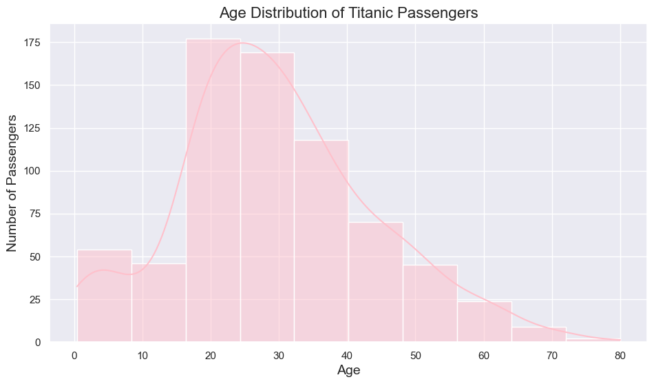

```python
#Graph for age distribution for passengers whose age information is available
sns.histplot(age_count['age'], bins=10, kde=True, color="pink")
plt.title('Age Distribution of Titanic Passengers', fontsize=16)
plt.xlabel('Age', fontsize=14)
plt.ylabel('Number of Passengers', fontsize=14)
plt.grid(True)
```

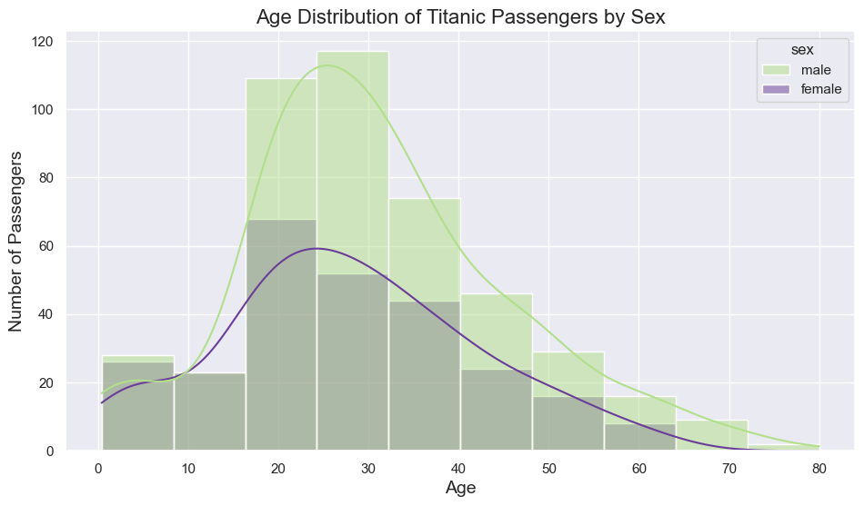

```python
# Age, subset sex
palette = sns.color_palette("Paired")
selected_colors = [palette[2], palette[9]]
sns.histplot(
    data=age_count,          # Data source
    x='age',                 # Variable for the x-axis
    hue='sex',               # Variable to color by sex
    bins=10,                 # Number of bins
    kde=True,                # Include Kernel Density Estimate
    palette=selected_colors  # Use the selected colors for the hue
)
plt.title('Age Distribution of Titanic Passengers by Sex', fontsize=16)
plt.xlabel('Age', fontsize=14)
plt.ylabel('Number of Passengers', fontsize=14)
plt.grid(True)
```

### **Question 5 - Show the age distribution per ticket class, per sex. What do you find?**

```python
sns.color_palette("Paired")
```

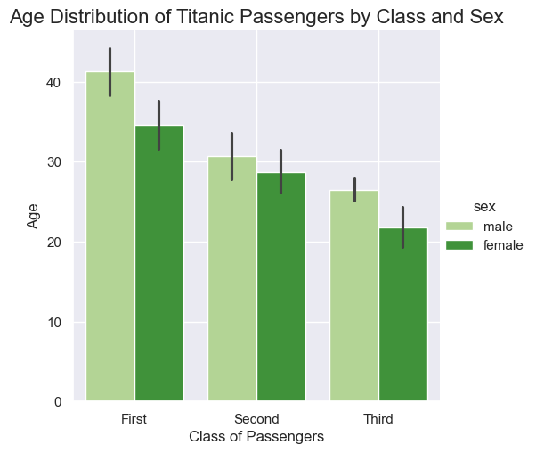

```python
# Write your code here
palette = sns.color_palette("Paired")
selected_colors = [palette[2], palette[3]]
sns.catplot(
    data=age_count,
    x='class',
    order=["First", "Second", "Third"],
    y='age',
    hue='sex',
    kind="bar",
    palette=selected_colors
)
plt.title('Age Distribution of Titanic Passengers by Class and Sex', fontsize=16)
plt.ylabel('Age', fontsize=12)
plt.xlabel('Class of Passengers', fontsize=12)
plt.grid(True)
```

### **Question 6 - How do the sex, ticket class, and age of a passenger affect their chance of survival? Try to use a single plot to answer this question.**

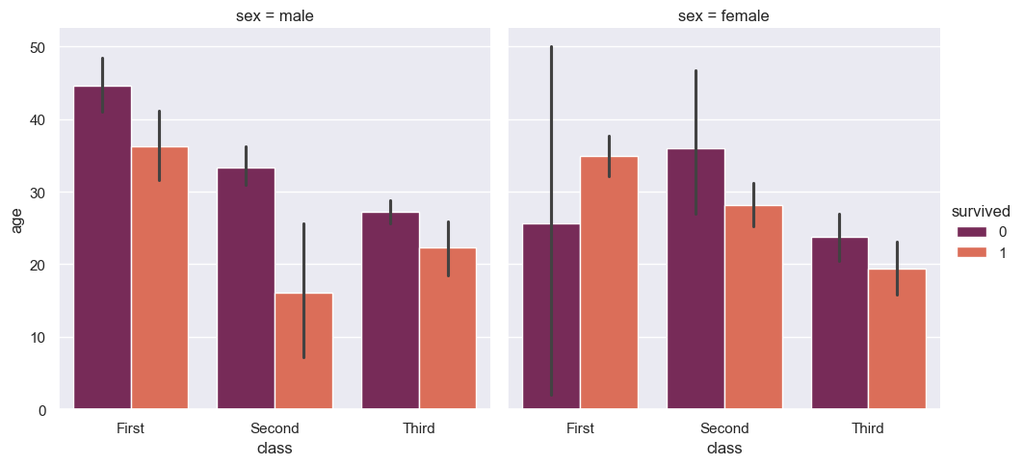

```python
a = sns.catplot(x="class", y="age", hue="survived", order=["First", "Second","Third"],
            kind="bar", col="sex", data=df, palette="rocket")
```

### **Question 7 - Which ticket class did most of the largest families get? And which ticket class has the lowest proportion of female passengers who travelled solo out of all the female passengers in that class?**

```python
df.head()
```

|  | survived | pclass | sex | age | sibsp | parch | fare | embarked | class | who | adult_male | deck | embark_town | alive | alone |
| --- | --- | --- | --- | --- | --- | --- | --- | --- | --- | --- | --- | --- | --- | --- | --- |
| 0 | 0 | 3 | male | 22.0 | 1 | 0 | 7.2500 | S | Third | man | True | NaN | Southampton | no | False |
| 1 | 1 | 1 | female | 38.0 | 1 | 0 | 71.2833 | C | First | woman | False | C | Cherbourg | yes | False |
| 2 | 1 | 3 | female | 26.0 | 0 | 0 | 7.9250 | S | Third | woman | False | NaN | Southampton | yes | True |
| 3 | 1 | 1 | female | 35.0 | 1 | 0 | 53.1000 | S | First | woman | False | C | Southampton | yes | False |
| 4 | 0 | 3 | male | 35.0 | 0 | 0 | 8.0500 | S | Third | man | True | NaN | Southampton | no | True |

```python
# Write your code here

#Find max family, parch & sibsp
max_parch_size = df['parch'].max()
print ("Max parents and children is", max_parch_size)
max_sibsp_size = df['sibsp'].max()
print ("Max siblings and spouse is", max_sibsp_size)
```

```
Max parents and children is 6
Max siblings and spouse is 8
```

```python
import pandas as pd
import seaborn as sns
import matplotlib.pyplot as plt
```

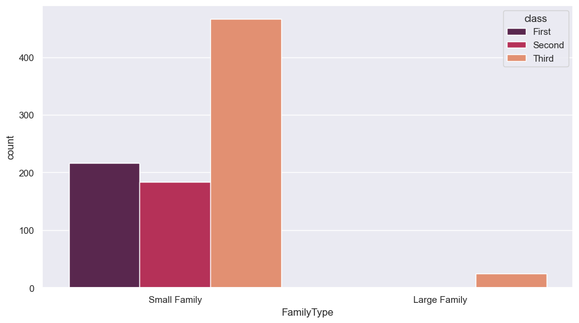

```python
#create family size columns
df['FamilySize'] = df['sibsp'] + df['parch'] + 1

#define family type based on FamilySize
def classify_family(row):
    if row['FamilySize'] <= 6:
        return "Small Family"
    else:
        return "Large Family"

df['FamilyType'] = ["Small Family" if size <=6 else "Large Family" for size in df['FamilySize']]

#plot the distribution of ticket classes for large families
sns.countplot(data=df, x='FamilyType', hue='class', palette='rocket', hue_order=['First', 'Second', 'Third'])
```

```python
df.sample(10)
```

[output not shown]

```
126
```

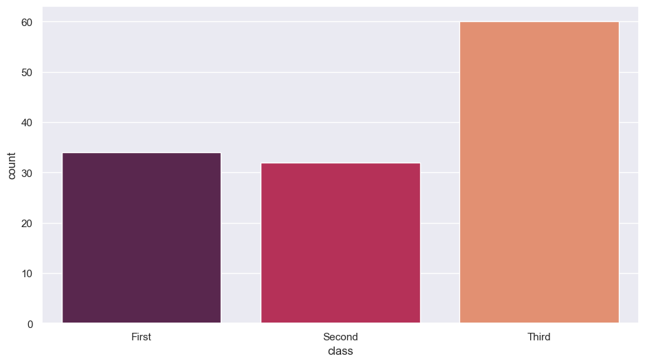

```python
#find solo female travellers
mask = (df['sex'] == 'female') & (df['sibsp'] == 0) & (df['parch'] == 0)
solo_females = df[mask]
total_solo_females = mask.sum()
print(total_solo_females)

sns.countplot(data=solo_females, x='class', palette='rocket', order=['First', 'Second', 'Third'])
```

## **Part 2: Pokemon Data Analysis**

[figure not shown]

For this part of the assignment you will be exploring the Pokemon dataset and answering the following questions.

**-Make sure you have downloaded the Pokemon dataset from UROX under your assignment module after week 7.**

**-Load the dataset into your Google Colab, before reading it into pandas**

**-Answer all questions using charts**

### Pokemon Data View

[figure not shown]

```python
#Upload the pokemon dataset from UROX to google colab then run this cell
file_path = r"C:\Users\aiswa\Music\SC-20241013T012708Z-001\SC\data\pokemon_data.csv"
df = pd.read_csv(file_path)

df.sample(10)
```

|  | # | Name | Type 1 | Type 2 | HP | Attack | Defense | Sp. Atk | Sp. Def | Speed | Generation | Legendary |
| --- | --- | --- | --- | --- | --- | --- | --- | --- | --- | --- | --- | --- |
| 621 | 560 | Scrafty | Dark | Fighting | 65 | 90 | 115 | 45 | 115 | 58 | 5 | False |
| 481 | 433 | Chingling | Psychic | NaN | 45 | 30 | 50 | 65 | 50 | 45 | 4 | False |
| 221 | 206 | Dunsparce | Normal | NaN | 100 | 70 | 70 | 65 | 65 | 45 | 2 | False |
| 436 | 391 | Monferno | Fire | Fighting | 64 | 78 | 52 | 78 | 52 | 81 | 4 | False |
| 70 | 65 | Alakazam | Psychic | NaN | 55 | 50 | 45 | 135 | 95 | 120 | 1 | False |
| 272 | 252 | Treecko | Grass | NaN | 40 | 45 | 35 | 65 | 55 | 70 | 3 | False |
| 318 | 294 | Loudred | Normal | NaN | 84 | 71 | 43 | 71 | 43 | 48 | 3 | False |
| 79 | 73 | Tentacruel | Water | Poison | 80 | 70 | 65 | 80 | 120 | 100 | 1 | False |
| 188 | 174 | Igglybuff | Normal | Fairy | 90 | 30 | 15 | 40 | 20 | 15 | 2 | False |
| 497 | 448 | Lucario | Fighting | Steel | 70 | 110 | 70 | 115 | 70 | 90 | 4 | False |

### **Question 8 - Create a bar chart or pie chart showcasing the percentage of each Generation of pokemon present in the data?**

[output not shown]

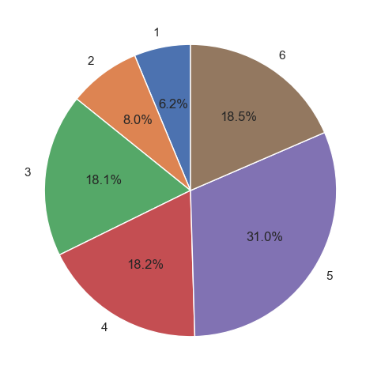

```python
#Write your code here
#Pie chart
generation_percentage = df.groupby("Generation")['Percentage'].sum()
plt.pie(generation_percentage,
        labels=generation_percentage.index,
        autopct='%.1f%%',
        startangle=90)
```

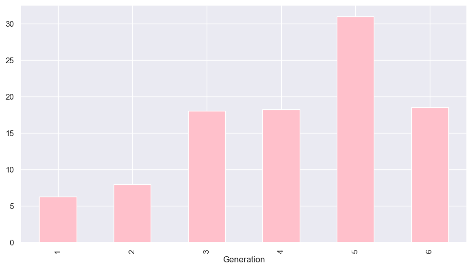

```python
#2nd way bar chart
generation_percentage.plot(kind='bar', color='pink')
```

### **Question 9 - Which Type of Pokemon has the highest average HP, Attack, Defense?**

```python
max_parch_size = df['parch'].max()
print ("Max parents and children is", max_parch_size)
max_sibsp_size = df['sibsp'].max()
print ("Max siblings and spouse is", max_sibsp_size)
```

```python
# Write your code here
#cars.groupby ("model") [[("mpg")]].mean()
#Group by Type and calculate the mean for each stat
a = df.groupby("Type 1")[[("HP")]].mean()
b = df.groupby("Type 1")[[("Attack")]].mean()
c = df.groupby("Type 1")[[("Defense")]].mean()
print (a,b,c)
```

```
                 HP
Type 1
Bug       56.884058
Dark      66.806452
Dragon    83.312500
Electric  59.795455
Fairy     74.117647
Fighting  69.851852
Fire      69.903846
Flying    70.750000
Ghost     64.437500
Grass     67.271429
Ground    73.781250
Ice       72.000000
Normal    77.275510
Poison    67.250000
Psychic   70.631579
Rock      65.363636
Steel     65.222222
Water     72.062500               Attack
Type 1
Bug        70.971014
Dark       88.387097
Dragon    112.125000
Electric   69.090909
Fairy      61.529412
Fighting   96.777778
Fire       84.769231
Flying     78.750000
Ghost      73.781250
Grass      73.214286
Ground     95.750000
Ice        72.750000
Normal     73.469388
Poison     74.678571
Psychic    71.456140
Rock       92.863636
Steel      92.703704
Water      74.151786              Defense
Type 1
Bug        70.724638
Dark       70.225806
Dragon     86.375000
Electric   66.295455
Fairy      65.705882
Fighting   65.925926
Fire       67.769231
Flying     66.250000
Ghost      81.187500
Grass      70.800000
Ground     84.843750
Ice        71.416667
Normal     59.846939
Poison     68.821429
Psychic    67.684211
Rock      100.795455
Steel     126.370370
Water      72.946429
```

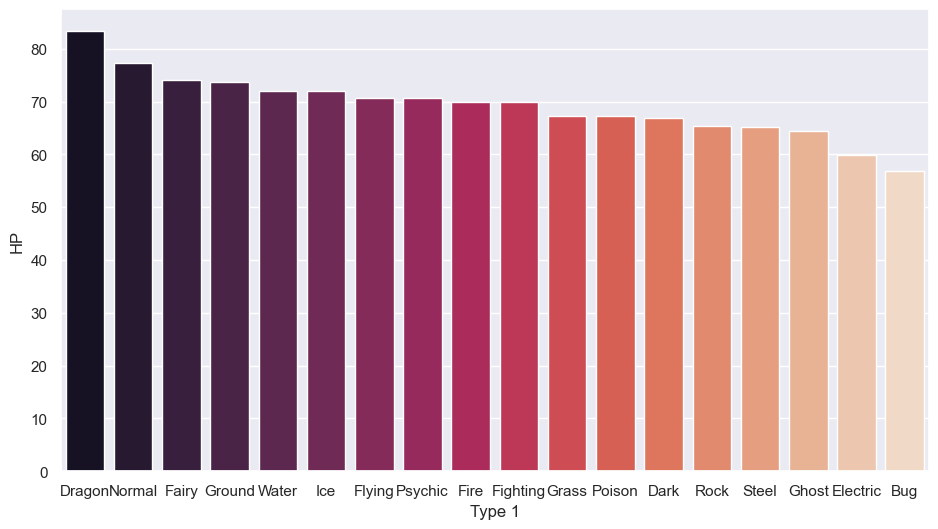

```python
a = a.sort_values(by='HP', ascending=False)
sns.barplot(data=a, x='Type 1', y='HP', palette='rocket')
#Dragon pokemon has the highest mean HP
```

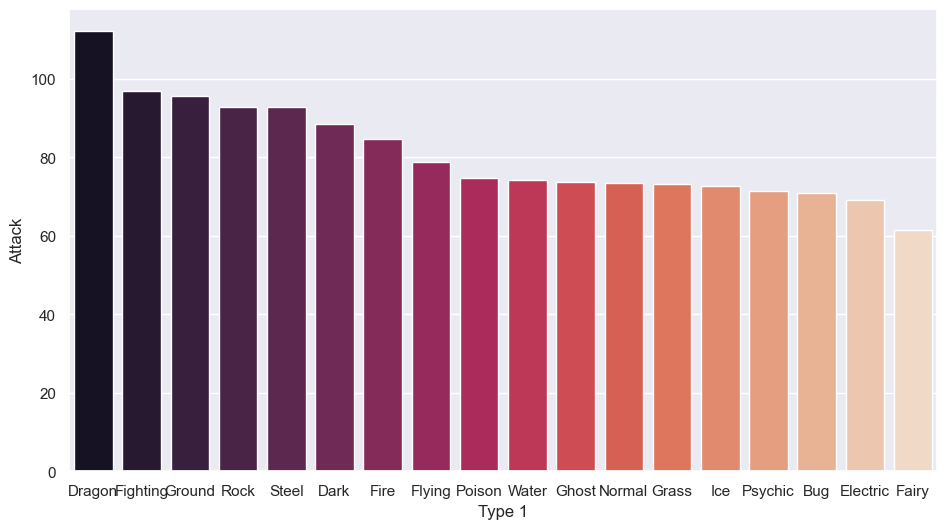

```python
b = b.sort_values(by='Attack', ascending=False)
sns.barplot(data=b, x='Type 1', y='Attack', palette='rocket')
#Dragon pokemon has the highest mean attack
```

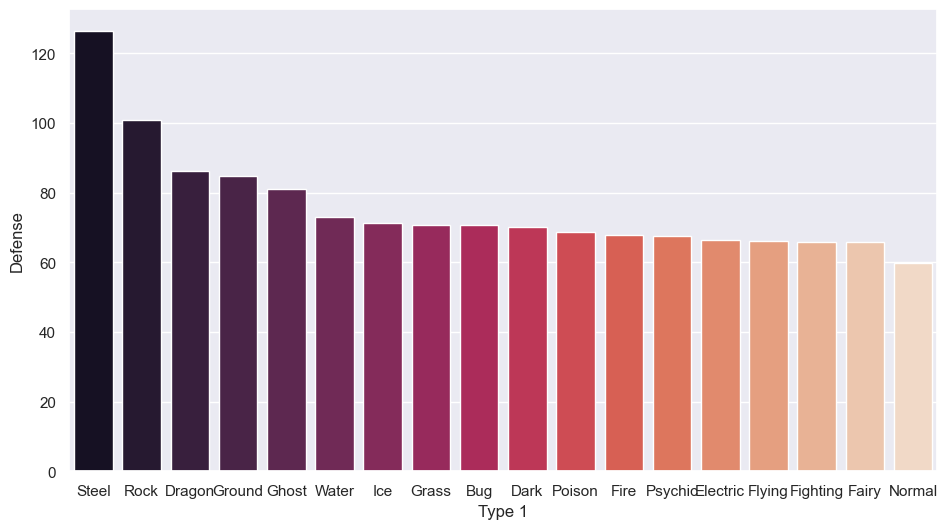

```python
c = c.sort_values(by='Defense', ascending=False)
sns.barplot(data=c, x='Type 1', y='Defense', palette='rocket')
#Steel pokemon has the highest mean defense
```

### **Question 10 - How many legendary Pokemon are there in the dataset? Which is the highest Type 1 of Legendary pokemon.?**

Answer all questions using charts from seaborn

```python
# Write your code here
df.sample(10)
```

|  | # | Name | Type 1 | Type 2 | HP | Attack | Defense | Sp. Atk | Sp. Def | Speed | Generation | Legendary | Percentage |
| --- | --- | --- | --- | --- | --- | --- | --- | --- | --- | --- | --- | --- | --- |
| 99 | 92 | Gastly | Ghost | Poison | 30 | 35 | 30 | 100 | 35 | 80 | 1 | False | 0.037608 |
| 95 | 88 | Grimer | Poison | NaN | 80 | 80 | 50 | 40 | 50 | 25 | 1 | False | 0.037608 |
| 530 | 478 | Froslass | Ice | Ghost | 70 | 80 | 70 | 80 | 70 | 110 | 4 | False | 0.150432 |
| 709 | 645 | LandorusTherian Forme | Ground | Flying | 89 | 145 | 90 | 105 | 80 | 91 | 5 | True | 0.188041 |
| 541 | 484 | Palkia | Water | Dragon | 90 | 120 | 100 | 150 | 120 | 100 | 4 | True | 0.150432 |
| 310 | 286 | Breloom | Grass | Fighting | 60 | 130 | 80 | 60 | 60 | 70 | 3 | False | 0.112824 |
| 655 | 594 | Alomomola | Water | NaN | 165 | 75 | 80 | 40 | 45 | 65 | 5 | False | 0.188041 |
| 43 | 38 | Ninetales | Fire | NaN | 73 | 76 | 75 | 81 | 100 | 100 | 1 | False | 0.037608 |
| 215 | 200 | Misdreavus | Ghost | NaN | 60 | 60 | 60 | 85 | 85 | 85 | 2 | False | 0.075216 |
| 407 | 372 | Shelgon | Dragon | NaN | 65 | 95 | 100 | 60 | 50 | 50 | 3 | False | 0.112824 |

```python
legendary_count = df['Legendary'].sum()
print(f"Number of Legendary Pokémon: {legendary_count}")
```

```
Number of Legendary Pokémon: 65
```

```python
legendary_count = df.groupby("Type 1")['Legendary'].sum().reset_index()
legendary_count
```

|  | Type 1 | Legendary |
| --- | --- | --- |
| 0 | Bug | 0 |
| 1 | Dark | 2 |
| 2 | Dragon | 12 |
| 3 | Electric | 4 |
| 4 | Fairy | 1 |
| 5 | Fighting | 0 |
| 6 | Fire | 5 |
| 7 | Flying | 2 |
| 8 | Ghost | 2 |
| 9 | Grass | 3 |
| 10 | Ground | 4 |
| 11 | Ice | 2 |
| 12 | Normal | 2 |
| 13 | Poison | 0 |
| 14 | Psychic | 14 |
| 15 | Rock | 4 |
| 16 | Steel | 4 |
| 17 | Water | 4 |

```python
max_legendary_count = legendary_count['Legendary'].max()
print (max_legendary_count)
```

```
14
```

```python
max_legendary_count = legendary_count['Legendary'].max()
print(f"Type with Maximum Legendary Pokémon: {legendary_count.iloc[max_legendary_count]['Type 1']}")
```

```
Type with Maximum Legendary Pokémon: Psychic
```

```python
!pip install nbconvert[webpdf]
!pip install playwright
```

[output not shown]